# Project 5: Communicate data findings - Flights Dataset

## by: Amnah Aldayri

## Preliminary Wrangling

> Flights Dataset consists of flight arrival and departure details for all commercial flights within the USA, from October 1987 to April 2008. This is a large dataset: there are nearly 120 million records in total, and takes up 1.6 gigabytes of space compressed and 12 gigabytes when uncompressed. In this project, we are using two datasets for two years 2007 and 2008. The Total number of observations is 14,462,943 with 29 features. Data visualization is an important skill that is used in many parts of the data analysis process, which will utilities in this project.

```python
# import all packages and set plots to be embedded inline
import numpy as np
import pandas as pd
import matplotlib.pyplot as plt
import seaborn as sb

%matplotlib inline
```

```python
import warnings
warnings.simplefilter(action='ignore', category=FutureWarning)
```

> Load in your dataset and describe its properties through the questions below. Try and motivate your exploration goals through this section.

```python
# Read CSV files
df_2007 = pd.read_csv('2007.csv.bz2')
```

```python
df_2008 = pd.read_csv('2008.csv.bz2')
```

```python
# Show first five records of the dataset
df_2007.head()
```

|  | Year | Month | DayofMonth | DayOfWeek | DepTime | CRSDepTime | ArrTime | CRSArrTime | UniqueCarrier | FlightNum | ... | TaxiIn | TaxiOut | Cancelled | CancellationCode | Diverted | CarrierDelay | WeatherDelay | NASDelay | SecurityDelay | LateAircraftDelay |
| --- | --- | --- | --- | --- | --- | --- | --- | --- | --- | --- | --- | --- | --- | --- | --- | --- | --- | --- | --- | --- | --- |
| 0 | 2007 | 1 | 1 | 1 | 1232.0 | 1225 | 1341.0 | 1340 | WN | 2891 | ... | 4 | 11 | 0 | NaN | 0 | 0 | 0 | 0 | 0 | 0 |
| 1 | 2007 | 1 | 1 | 1 | 1918.0 | 1905 | 2043.0 | 2035 | WN | 462 | ... | 5 | 6 | 0 | NaN | 0 | 0 | 0 | 0 | 0 | 0 |
| 2 | 2007 | 1 | 1 | 1 | 2206.0 | 2130 | 2334.0 | 2300 | WN | 1229 | ... | 6 | 9 | 0 | NaN | 0 | 3 | 0 | 0 | 0 | 31 |
| 3 | 2007 | 1 | 1 | 1 | 1230.0 | 1200 | 1356.0 | 1330 | WN | 1355 | ... | 3 | 8 | 0 | NaN | 0 | 23 | 0 | 0 | 0 | 3 |
| 4 | 2007 | 1 | 1 | 1 | 831.0 | 830 | 957.0 | 1000 | WN | 2278 | ... | 3 | 9 | 0 | NaN | 0 | 0 | 0 | 0 | 0 | 0 |

5 rows × 29 columns

```python
# Number of row and column in the dataset
df_2007.shape
```

```
(7453215, 29)
```

```python
# Show first five records of the dataset
df_2008.head()
```

|  | Year | Month | DayofMonth | DayOfWeek | DepTime | CRSDepTime | ArrTime | CRSArrTime | UniqueCarrier | FlightNum | ... | TaxiIn | TaxiOut | Cancelled | CancellationCode | Diverted | CarrierDelay | WeatherDelay | NASDelay | SecurityDelay | LateAircraftDelay |
| --- | --- | --- | --- | --- | --- | --- | --- | --- | --- | --- | --- | --- | --- | --- | --- | --- | --- | --- | --- | --- | --- |
| 0 | 2008 | 1 | 3 | 4 | 2003.0 | 1955 | 2211.0 | 2225 | WN | 335 | ... | 4.0 | 8.0 | 0 | NaN | 0 | NaN | NaN | NaN | NaN | NaN |
| 1 | 2008 | 1 | 3 | 4 | 754.0 | 735 | 1002.0 | 1000 | WN | 3231 | ... | 5.0 | 10.0 | 0 | NaN | 0 | NaN | NaN | NaN | NaN | NaN |
| 2 | 2008 | 1 | 3 | 4 | 628.0 | 620 | 804.0 | 750 | WN | 448 | ... | 3.0 | 17.0 | 0 | NaN | 0 | NaN | NaN | NaN | NaN | NaN |
| 3 | 2008 | 1 | 3 | 4 | 926.0 | 930 | 1054.0 | 1100 | WN | 1746 | ... | 3.0 | 7.0 | 0 | NaN | 0 | NaN | NaN | NaN | NaN | NaN |
| 4 | 2008 | 1 | 3 | 4 | 1829.0 | 1755 | 1959.0 | 1925 | WN | 3920 | ... | 3.0 | 10.0 | 0 | NaN | 0 | 2.0 | 0.0 | 0.0 | 0.0 | 32.0 |

5 rows × 29 columns

```python
# Number of row and column in the dataset
df_2008.shape
```

```
(7009728, 29)
```

```python
# Make outer merged to df_2007 and df_2008 datasets
outer_merged = pd.merge(df_2007, df_2008, how="outer")
```

```python
# Show first five records of the dataset after marged them
outer_merged.head()
```

|  | Year | Month | DayofMonth | DayOfWeek | DepTime | CRSDepTime | ArrTime | CRSArrTime | UniqueCarrier | FlightNum | ... | TaxiIn | TaxiOut | Cancelled | CancellationCode | Diverted | CarrierDelay | WeatherDelay | NASDelay | SecurityDelay | LateAircraftDelay |
| --- | --- | --- | --- | --- | --- | --- | --- | --- | --- | --- | --- | --- | --- | --- | --- | --- | --- | --- | --- | --- | --- |
| 0 | 2007 | 1 | 1 | 1 | 1232.0 | 1225 | 1341.0 | 1340 | WN | 2891 | ... | 4.0 | 11.0 | 0 | NaN | 0 | 0.0 | 0.0 | 0.0 | 0.0 | 0.0 |
| 1 | 2007 | 1 | 1 | 1 | 1918.0 | 1905 | 2043.0 | 2035 | WN | 462 | ... | 5.0 | 6.0 | 0 | NaN | 0 | 0.0 | 0.0 | 0.0 | 0.0 | 0.0 |
| 2 | 2007 | 1 | 1 | 1 | 2206.0 | 2130 | 2334.0 | 2300 | WN | 1229 | ... | 6.0 | 9.0 | 0 | NaN | 0 | 3.0 | 0.0 | 0.0 | 0.0 | 31.0 |
| 3 | 2007 | 1 | 1 | 1 | 1230.0 | 1200 | 1356.0 | 1330 | WN | 1355 | ... | 3.0 | 8.0 | 0 | NaN | 0 | 23.0 | 0.0 | 0.0 | 0.0 | 3.0 |
| 4 | 2007 | 1 | 1 | 1 | 831.0 | 830 | 957.0 | 1000 | WN | 2278 | ... | 3.0 | 9.0 | 0 | NaN | 0 | 0.0 | 0.0 | 0.0 | 0.0 | 0.0 |

5 rows × 29 columns

```python
# Number of row and column in the dataset after marged them
outer_merged.shape
```

```
(14462943, 29)
```

```python
# Show information of the final dataset
outer_merged.info()
```

```
<class 'pandas.core.frame.DataFrame'>
Int64Index: 14462943 entries, 0 to 14462942
Data columns (total 29 columns):
 #   Column             Dtype
---  ------             -----
 0   Year               int64
 1   Month              int64
 2   DayofMonth         int64
 3   DayOfWeek          int64
 4   DepTime            float64
 5   CRSDepTime         int64
 6   ArrTime            float64
 7   CRSArrTime         int64
 8   UniqueCarrier      object
 9   FlightNum          int64
```

[output cut: 21 more lines]

```python
# Create a new data frame
data = outer_merged.copy()
```

### What is the structure of your dataset?

> In this project, we are using two datasets for two years 2007 and 2008.  
> There are 7,453,215 flight observations with 29 features in 2007 and There are 7,009,728 flight observations with 29 features in 2008.  
> The Total number of observations after the two datasets were merged is 14,462,943 with 29 features.

### What is/are the main feature(s) of interest in your dataset?

> Month, UniqueCarrier , DepDelay , ArrDelay, Cancelled,

### What features in the dataset do you think will help support your investigation into your feature(s) of interest?

> Origin, Dest, WeatherDelay, CarrierDelay, NASDelay, SecurityDelay, LateAircraftDelay,

## Univariate Exploration

[output not shown]

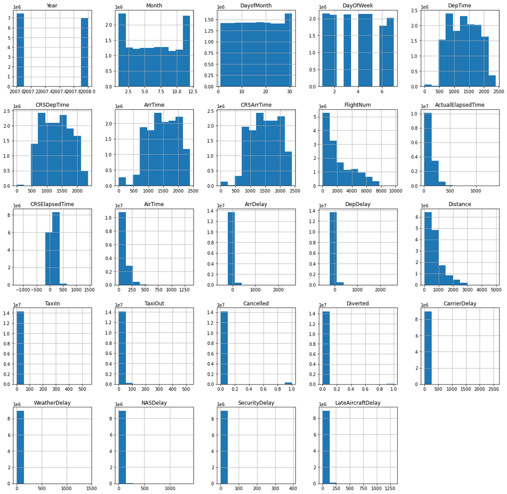

```python
# Histograms plot to explore each variable and their distributions
data.hist(figsize=(20,20))
```

> Histograms plot to explore each variable and their distributions.

### Does the number of flights vary each month?

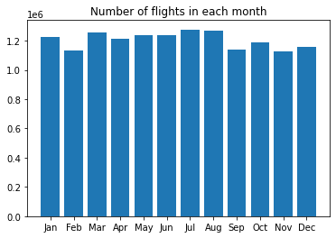

```python
width = 1
bins = np.arange(1, 14, width)
plt.hist(data['Month'], rwidth=.8 , bins=bins)
months_names = ['Jan', 'Feb', 'Mar', 'Apr', 'May', 'Jun', 'Jul', 'Aug', 'Sep', 'Oct', 'Nov', 'Dec']
plt.xticks(np.arange(1.5,max(bins),width), months_names);
plt.title('Number of flights in each month')
```

> Through this visualization, it is clear that the number of flights during 12 months are very close in 2007 and 2008.

### What is the most commonly used Carrier Company?

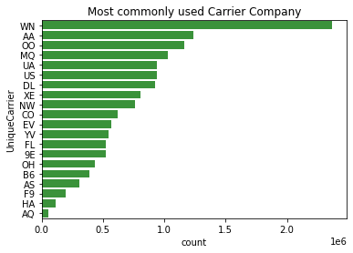

```python
base_color = sb.color_palette()[2]

UniqueCarrier = data['UniqueCarrier'].value_counts().index
sb.countplot(data=data, y='UniqueCarrier', color=base_color, order=UniqueCarrier);
plt.title('Most commonly used Carrier Company')
```

> From the diagram above, we can observe that WN is the most commonly used Carrier Company in 2007 and 2008.

```python
data['DepDelay'].describe()
```

```
count    1.416595e+07
mean     1.070695e+01
std      3.574838e+01
min     -5.340000e+02
25%     -4.000000e+00
50%     -1.000000e+00
75%      9.000000e+00
max      2.601000e+03
Name: DepDelay, dtype: float64
```

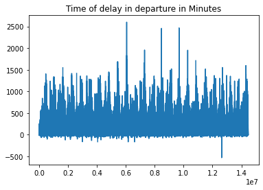

```python
# Line plot describe time of delay in departure in Minutes
data['DepDelay'].plot(kind='line')
plt.title('Time of delay in departure in Minutes')
plt.show()
```

```python
data['Cancelled'].describe()
```

```
count    1.446294e+07
mean     2.061697e-02
std      1.420982e-01
min      0.000000e+00
25%      0.000000e+00
50%      0.000000e+00
75%      0.000000e+00
max      1.000000e+00
Name: Cancelled, dtype: float64
```

[figure not shown]

```python
data['WeatherDelay'].plot(kind='line')
plt.title('Time of delay because of Weather in Minutes')
plt.show()
```

[figure not shown]

```python
data['ArrDelay'].plot(kind='line')
plt.title('Time of delay in arraival in Minutes')
plt.show()
```

### Discuss the distribution(s) of your variable(s) of interest. Were there any unusual points? Did you need to perform any transformations?

> No

## Bivariate Exploration

### Correlation between Month and weather Delay

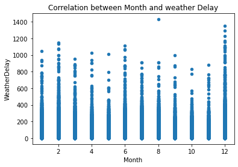

```python
# Scatter plot to describe the Correlation between Month and weather Delay
data.plot.scatter(x='Month',y='WeatherDelay')
plt.title('Correlation between Month and weather Delay')
plt.show()
```

> Scatter plot to describe the Correlation between Month and weather Delay

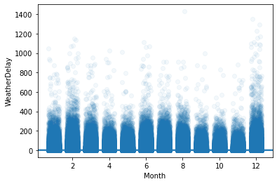

```python
sb.regplot(data = data, x = 'Month', y = 'WeatherDelay', truncate=False, x_jitter=0.3, scatter_kws={'alpha':1/20});
```

### Correlation between DepDelay and ArrDelay

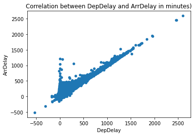

```python
# Scatter plot to describe the Correlation between DepDelay and ArrDelay
data.plot.scatter(x='DepDelay', y='ArrDelay')
plt.title('Correlation between DepDelay and ArrDelay in minutes)')
plt.show()
```

> Correlation between DepDelay and ArrDelay is a direct relationship, when DepDelay increased the ArrDelay increased.

```python
# Remove Outliers
outliers = (((data.DepDelay - data.DepDelay.mean()).abs() > data.DepDelay.std()*3) |
            ((data.ArrDelay - data.ArrDelay.mean()).abs() > data.ArrDelay.std()*3))
```

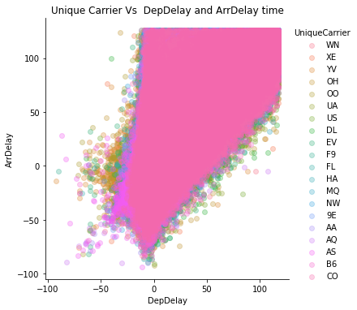

```python
# Plot data after remove outliers
sb.lmplot('DepDelay', 'ArrDelay', data=data[~outliers],
           fit_reg=False, hue='UniqueCarrier', scatter_kws={'alpha':0.3})
plt.title('Unique Carrier Vs  DepDelay and ArrDelay time')
plt.show()
```

> The Previous diagram show the value of Unique Carrier Vs DepDelay and ArrDelay time.

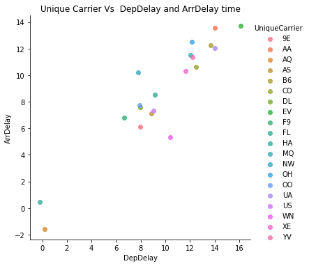

```python
# Plot the average value for each Unique Carrier according to DepDelay and ArrDelay
carrier_averages = data.groupby('UniqueCarrier').agg({'DepDelay':'mean', 'ArrDelay':'mean'}).reset_index()
sb.lmplot('DepDelay', 'ArrDelay', data=carrier_averages,
           fit_reg=False, hue='UniqueCarrier', )
plt.title('Unique Carrier Vs  DepDelay and ArrDelay time')
plt.show()
```

> The previous drawings show that there is a direct relationship between DepDelay and ArrDelay

### Talk about some of the relationships you observed in this part of the investigation. How did the feature(s) of interest vary with other features in the dataset?

> We observe that there is a correlation between Month and weather Delay, and there is a direct relationship between DepDelay and ArrDelay

### Did you observe any interesting relationships between the other features (not the main feature(s) of interest)?

> Yes , WeatherDelay.

## Multivariate Exploration

### Correlation between Time (Year , Month) and Delay type (CarrierDelay , WeatherDelay ,NASDelay , SecurityDelay , LateAircraftDelay)

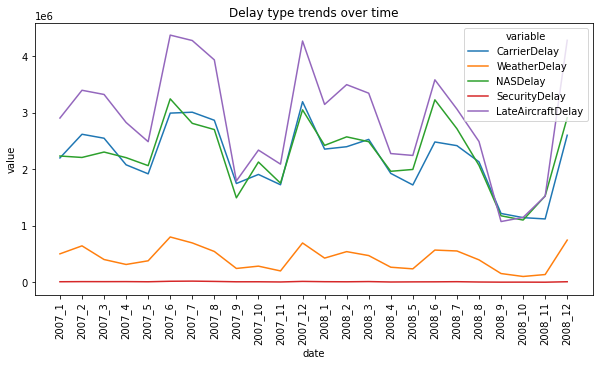

```python
# Line plot to describe different kind of delay
delays_over_time= data.groupby(['Year','Month']).sum().reset_index()
delays_over_time = pd.melt(delays_over_time, id_vars=['Year','Month'], value_vars=['CarrierDelay', 'WeatherDelay',"NASDelay",'SecurityDelay','LateAircraftDelay'])

delays_over_time['date'] = delays_over_time['Year'].astype(str) +"_" +delays_over_time['Month'].astype(str)
delays_over_time = delays_over_time.drop(['Year','Month'], axis=1)

plt.figure(figsize=(10,5))
plt.title('Delay type trends over time')
plt.xticks(rotation=90)
sb.lineplot(x='date', y='value', hue='variable', data=delays_over_time)
plt.show()
```

> From the diagram above, we can observe many types of delays, LateAircraftDelay is the highest one, While the SecurityDelay is the lowest one.

### Whish day of a week the departure delay happened frequently during the 12 months?

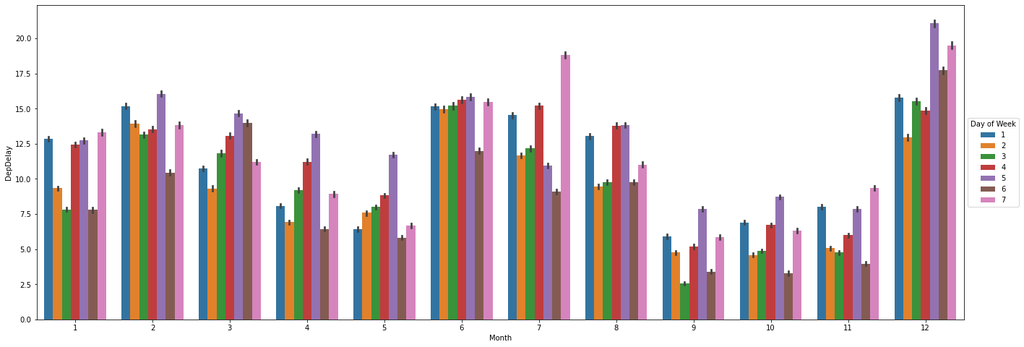

```python
# Adapted clustered bar chart
plt.figure(figsize=[23,8])
ax = sb.barplot(data = data, x = 'Month', y = 'DepDelay', hue = 'DayOfWeek')
ax.legend(loc='center left', bbox_to_anchor=(1, 0.5), title = 'Day of Week');
```

### Which month has the highest departure and arrival delay ?

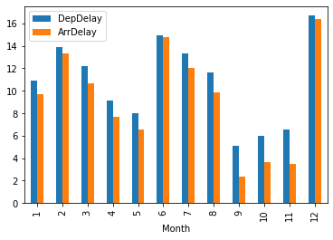

```python
data.groupby('Month').agg({'DepDelay':'mean', 'ArrDelay':'mean'}).plot.bar()
ax.legend(loc='center left', bbox_to_anchor=(1, 0.5), title = 'Delay');
plt.show()
```

> According to the diagram, December (12) is the most common month that has departure and arrival delay

### Talk about some of the relationships you observed in this part of the investigation. Were there features that strengthened each other in terms of looking at your feature(s) of interest?

> In this section we make a comparison between ['Year','Month'] and different type of delay ['CarrierDelay', 'WeatherDelay',"NASDelay",'SecurityDelay','LateAircraftDelay'] and provide a diagram Describe the Delay type trends over time.

### Were there any interesting or surprising interactions between features?

> No